# Report of Research: SQL

Valentin

02/02/2022

# Report of Research

## Second Part: Analysis with SQL

### Target question: **1. How do annual members and casual riders use Cyclistic bikes differently?**

After we have made the basic analysis we used RStudio to create a unique dataset containing the twelve months of the year withing a csv file with the following characteristics:

**name: bigDatasetCSV.csv, 5 595 062 observations of 19 variables**

This is the reason why now we need to use a tool different from a spreadsheet, we start using SQL to continue with our research. I uploaded our CSV file bigDatasetCSV.cvs and created a database to work with in SQLite named **bigDatasetCSV.db**

**1.** In the part 1. of the section Basic Analysis we saw that the percentage of casual riders was not big enough for December 2021; however, doing the same analysis annually with biDatasetCSV.db, we can see in the following annual pie chart that **45.2%** of riders are casual riders, which is a significant amount. To obtain these results I made queries in Sqlite and the visualizations were made in a dashboard using Tableau, these are interactive dashboards, so to have a better visualization you can visit Dashboard 1 in [tableau](https://public.tableau.com/views/Queries-2021-Type-of-Rider/Dashboard1?:language=es-ES&:display_count=n&:origin=viz_share_link).

The second graph indicates the quantity of casual and member rider for each of the 12 months, we can se that during the months November, December, January and February the casual riders decreases a lot. Meanwhile during May, June, July and August the quantity of each type of riders is pretty balanced.

The 3rd graph confirms that docked bikes are poorly used by both riders, but casual riders using this service could be a potential target.

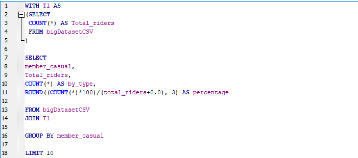

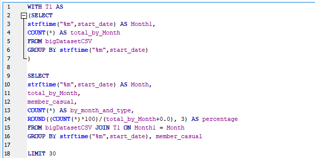

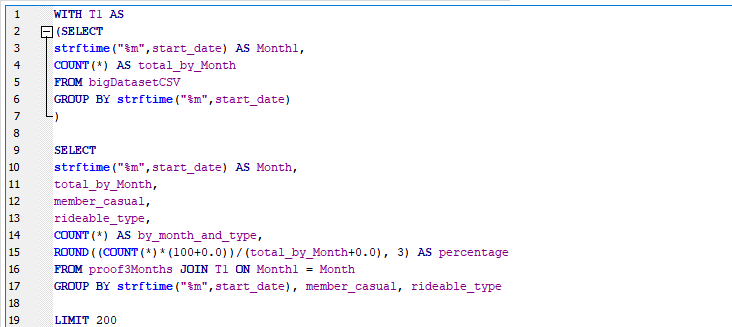

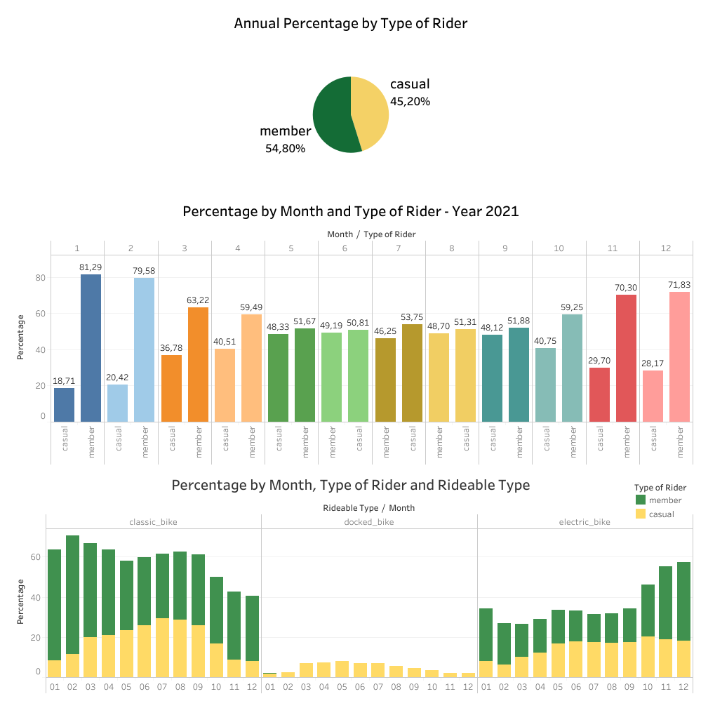

**2.** **Analysis by hours in a day**

To have a better visualization visit Dashboard 2 in [tableau](https://public.tableau.com/views/Queries-2021-Type-of-Rider/Dashboard2?:language=es-ES&:display_count=n&:origin=viz_share_link).

We observe that annually there is no big difference in the pattern of use for each type of rider, but we observe that the peak use is from 16:00 hours to 20:00 hours. However in the second visualization we observe that the pattern for each month is significantly different: during the months May, Jun, July, August and September,(note that this is coherent with the results found in Dashboard 1) the use of the service by casual riders increases a lot and in particular from 16:00 to 24:00 hours, the peak being from 16:00 to 20:00 hours.

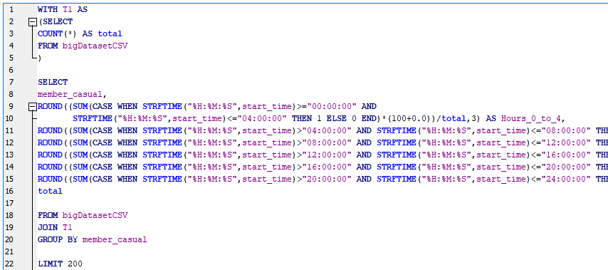

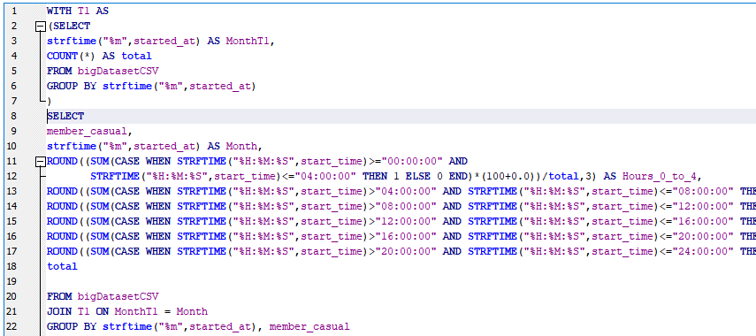

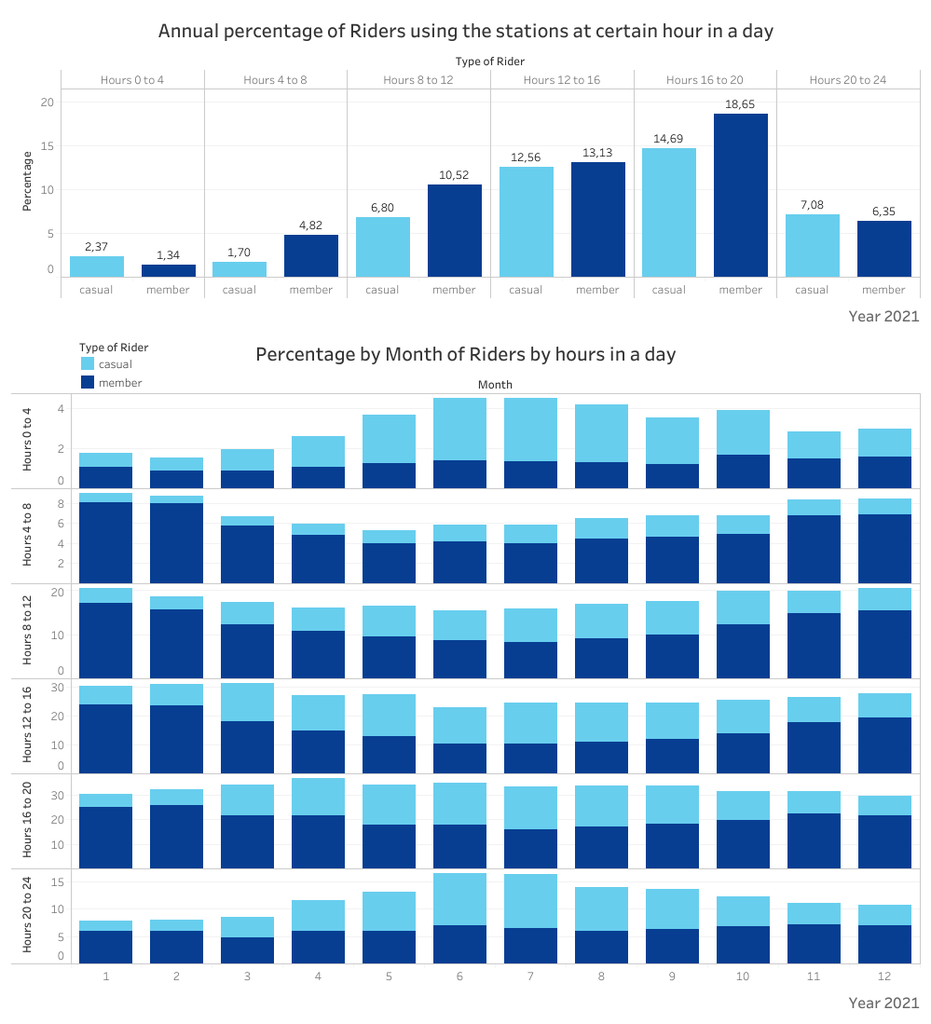

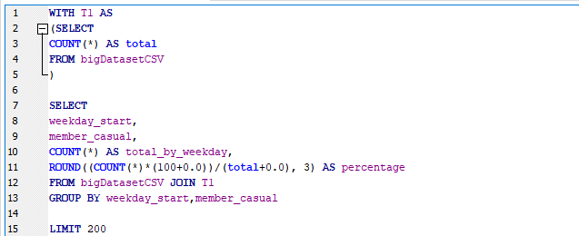

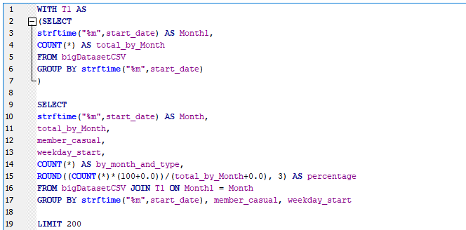

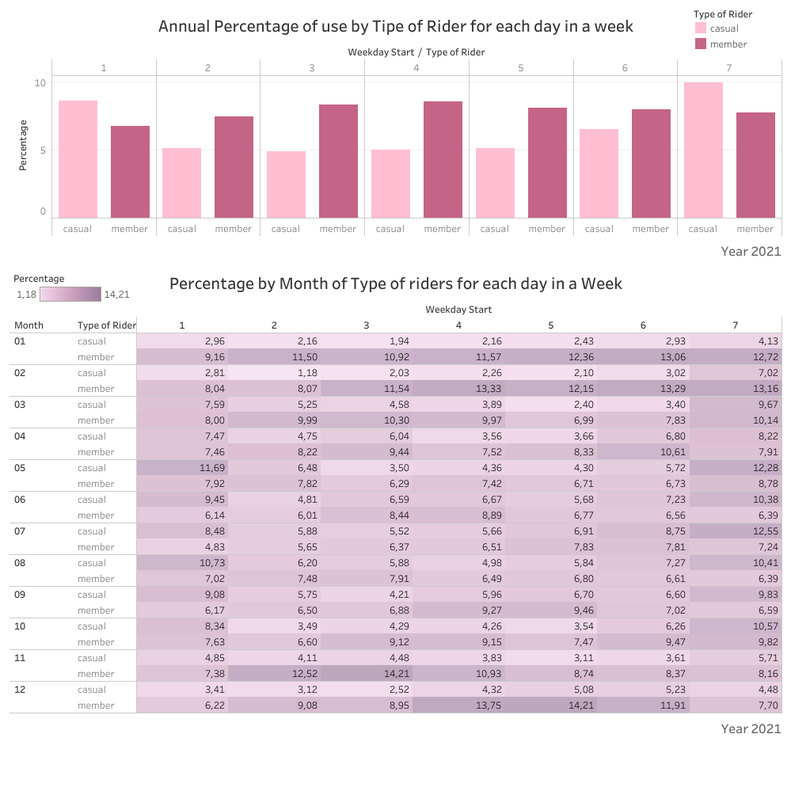

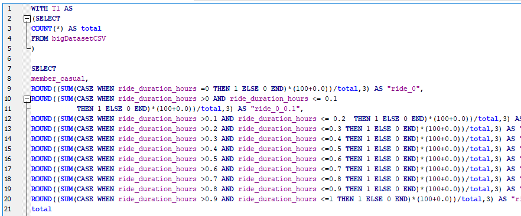

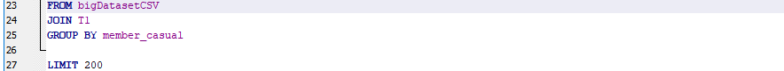

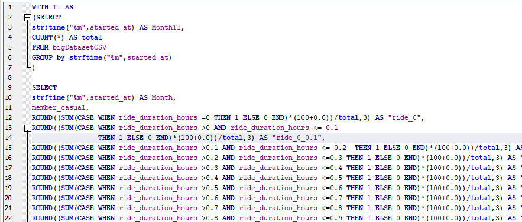

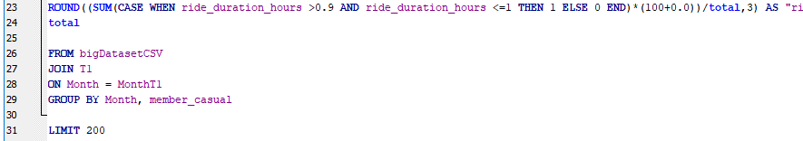

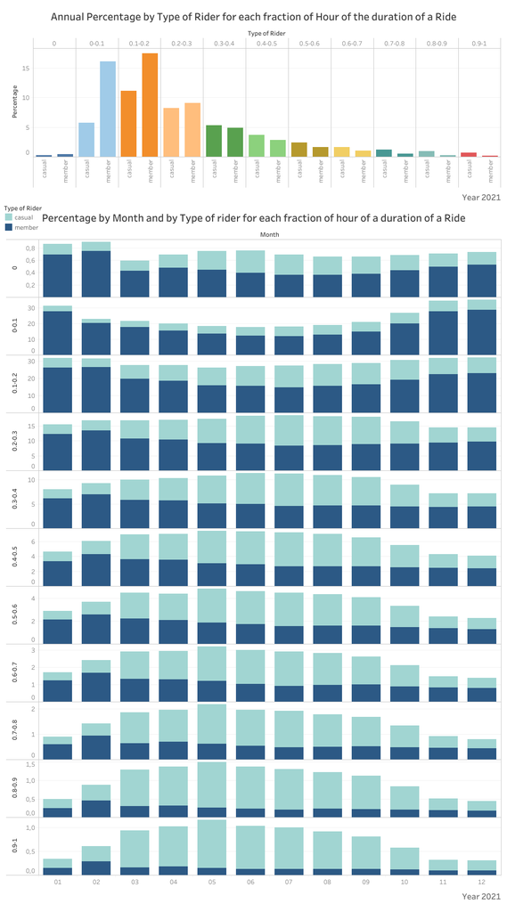